# LSL hands-on 2:

# Latency tests and how to LSL on a heavy 3D environment

## 1. Recap: Aligning data streams sampled from different sources

Data sampling devices have different:

- Sampling rates (e.g. 1000Hz for EEG, 60FPS in Unity, 90Hz for Eye-Tracking, etc.)
- CPU clocks (diff. CPU clocks between computers, EEG amplifiers, etc.)

[figure not shown]

- Data streaming over network -> LAN/WLAN latencies

## 2. Recap: Lab Streaming Layer (LSL) as data streams aligning solution

Why LSL?

- Manually aligning data streams can be really time consuming
- Standard tool in the science community: community support :)

Also:

- open source
- cross platform (Win, Linux, MacOS, Android, iOS) and multi language APIs (C, C++, Python, Java, C#, MATLAB)
- many GUI tools supporting standard technologies and devices
- XDF data recordings (meant to be a standard format in science)

Source: https://labstreaminglayer.readthedocs.io/info/intro.html#what-is-lsl

## 3. How to use LSL (Unity with EEG use case)

How to use LSL? General requirements:

- LabRecorder app: https://github.com/labstreaminglayer/App-LabRecorder/releases

[figure not shown]

- `liblsl` library (https://github.com/sccn/liblsl/releases/latest) with code defining your data streams

  and/or

## 3. How to use LSL (Unity with EEG use case)

How to use LSL? General requirements:

```
and/or
```

- LSL community app (e.g. OpenVibe Data Acquisition Server: http://openvibe.inria.fr/downloads/)

[figure not shown]

## 3. How to use LSL (Unity with EEG use case)

Code example in C# defining a data stream:

```
using LSL;
public class yourClass
{
    // declare your data stream
    private liblsl.StreamInfo lslStreamInfo; // stream information
    private liblsl.StreamOutlet lslOutlet; // actual stream to send out
    void startingMethod() { // normally Start() in Unity
        // instantiate your stream
        lslStreamInfo = new liblsl.StreamInfo(
            sName, // name of your stream
            sType, // stream type
            nValues, // you send an array, so how many values it contains
            nominalRate, // constant or not
            LslChannelFormat, // if you send integers, floats, etc.
            uuid); // universally unique identifier
        lslOutlet = new liblsl.StreamOutlet(streamInfo);
    }
    void sendingMethod() { // normally FixedUpdate() in Unity
        var data = new float[nValues]; // data you want to send
        lslOutlet.push_sample(data); // send/stream your data
    }
}
```

More examples https://labstreaminglayer.readthedocs.io/dev/examples.html

API reference: https://labstreaminglayer.readthedocs.io/projects/liblsl/index.html

## 3. How to use LSL (Unity with EEG use case)

Use case (our test setup):

[figure not shown]

## 3. How to use LSL (Unity with EEG use case)

Where to place `liblsl` on Unity:

- `liblsl`library

[figure not shown]

- `LSL.cs` class -> https://github.com/labstreaminglayer/liblsl-Csharp/blob/master/LSL.cs

[figure not shown]

## 3. How to use LSL (Unity with EEG use case)

How to make OpenVibe Acquisition Server (AVAS) work with `liblsl`:

- `liblsl` library replacement

[figure not shown]

**Important:** make sure you share the same `liblsl` version between the LabRecorder, Unity and your scripts and/or any community LSL app. You can always overwrite the shipped one if you're unsure.

## 3. How to use LSL (Unity with EEG use case)

How to make OpenVibe Acquisition Server (AVAS) work with `liblsl`:

- LSL configuration file library "hack"

[figure not shown]

## 4. Test design

Background (2D vs 3D):

[figure not shown]

Unity 2D project used for testing: https://github.com/mvidaldp/lsl_in_unity

## 4. Test design

Audio (old vs new):

[figure not shown]

Unity 2D project used for testing: https://github.com/mvidaldp/lsl_in_unity

## 5. Recap: How does the data look like?

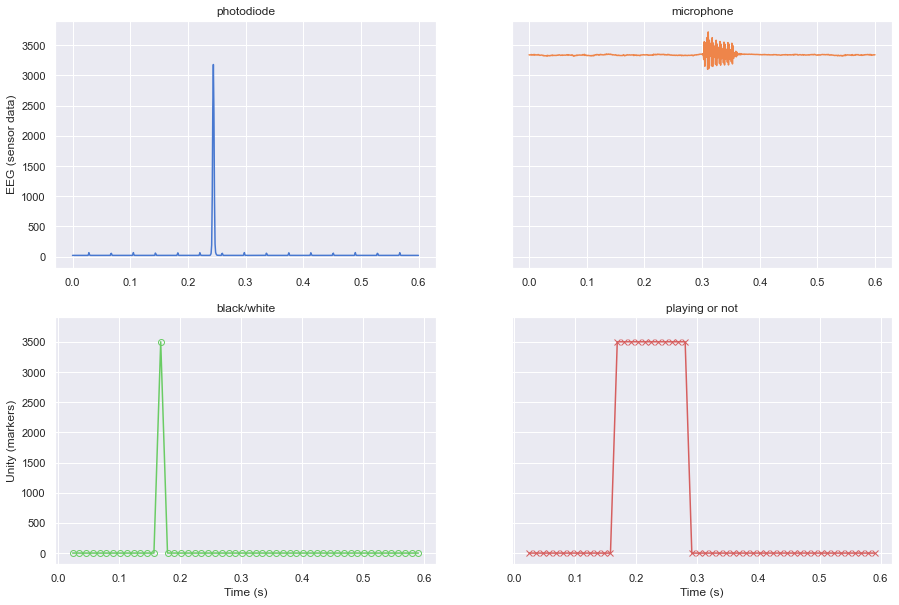

## 5. Recap: How does the data look like?

[figure not shown]

*What do we look for exactly?*

- **Image latency:** time between unity color markers and the diode peaks
- **Audio latency:** time between unity audio playing markers and microphone peaks

## 6. Results

How constant are the framerates?

**Unity (90FPS ~ 11.11ms vs 50FPS ~ 20ms )**

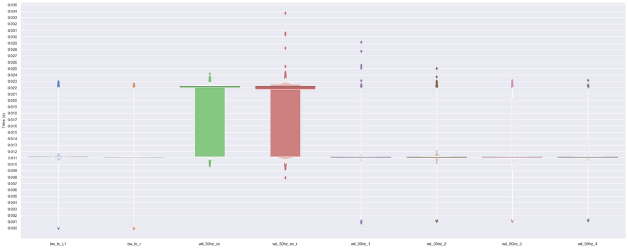

## 6. Results

How constant are the framerates?

**Unity (90FPS ~ 11.11ms vs 50FPS ~ 20ms )**

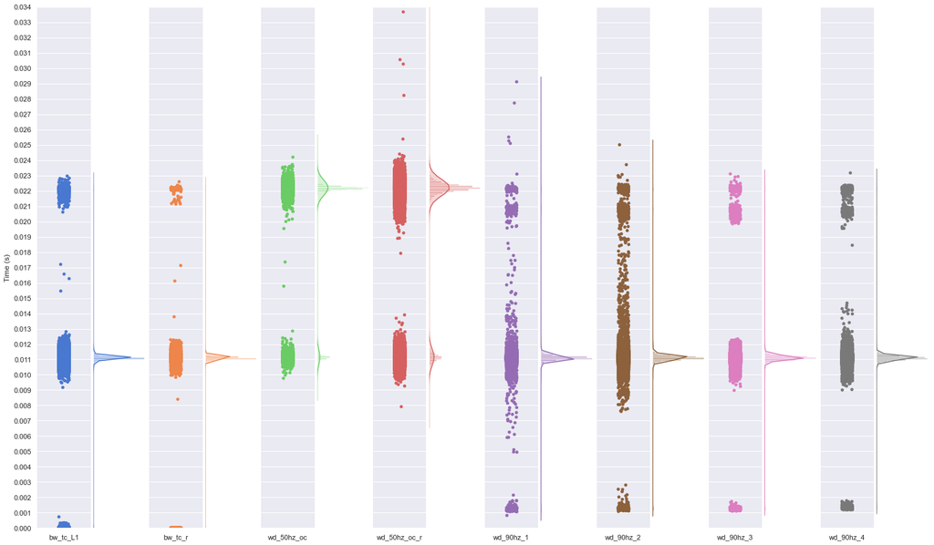

## 6. Results

**How to enforce 90FPS instead of 50FPS (default) in Unity?**

[figure not shown]

**Important:** Although this parameter works, it makes Unity more prone to skip frames. Also, on the Unity Editor Player we could not run Westdrive on a `NVIDIA RTX 2080Ti`! However, it worked on the build :)

## 6. Results

Latencies

**Time distance between unity color markers and the diode peaks**

|  | bw_tc_L1 | bw_tc_r | wd_90hz_1 | wd_90hz_2 | wd_90hz_3 | wd_90hz_4 | AVG |
| --- | --- | --- | --- | --- | --- | --- | --- |
| count | 7706.000000 | 856.000000 | 1218.000000 | 2407.000000 | 2385.000000 | 2414.000000 | 2831.000000 |
| mean | 0.075361 | 0.085203 | 0.083596 | 0.083538 | 0.083470 | 0.083755 | 0.082487 |
| std | 0.000301 | 0.000601 | 0.000715 | 0.000785 | 0.000491 | 0.000703 | 0.000599 |
| min | 0.074084 | 0.084378 | 0.081619 | 0.078895 | 0.081069 | 0.080676 | 0.080120 |
| 25% | 0.075118 | 0.084939 | 0.083269 | 0.083209 | 0.083205 | 0.083406 | 0.082191 |
| 50% | 0.075364 | 0.085185 | 0.083534 | 0.083479 | 0.083460 | 0.083697 | 0.082453 |
| 75% | 0.075610 | 0.085423 | 0.083796 | 0.083741 | 0.083716 | 0.083968 | 0.082709 |
| max | 0.075989 | 0.096419 | 0.093438 | 0.094801 | 0.094282 | 0.095103 | 0.091672 |

## 6. Results

Latencies

**Time distance between unity color markers and the diode peaks**

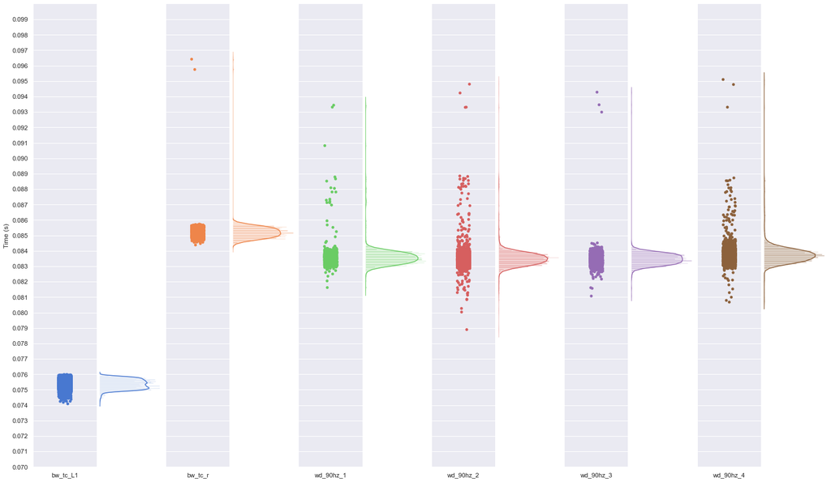

## 6. Results

Latencies

**Time distance between unity audio playing markers and microphone peaks**

|  | bw_tc_L1 | bw_tc_r | wd_90hz_1 | wd_90hz_2 | wd_90hz_3 | wd_90hz_4 | AVG |
| --- | --- | --- | --- | --- | --- | --- | --- |
| count | 7744.000000 | 860.000000 | 1185.000000 | 2416.000000 | 2395.000000 | 2423.000000 | 2837.166667 |
| mean | 0.141957 | 0.151279 | 0.188110 | 0.134765 | 0.135461 | 0.135430 | 0.147833 |
| std | 0.005408 | 0.003756 | 0.006367 | 0.003473 | 0.005617 | 0.003710 | 0.004722 |
| min | 0.125079 | 0.140721 | 0.174040 | 0.106402 | 0.112354 | 0.101700 | 0.126716 |
| 25% | 0.138423 | 0.148477 | 0.183037 | 0.132218 | 0.131132 | 0.132934 | 0.144370 |
| 50% | 0.141960 | 0.151101 | 0.188238 | 0.134754 | 0.134877 | 0.135556 | 0.147748 |
| 75% | 0.145502 | 0.153893 | 0.193318 | 0.137348 | 0.139080 | 0.138031 | 0.151196 |
| max | 0.197155 | 0.162342 | 0.199990 | 0.143965 | 0.162306 | 0.144170 | 0.168321 |

## 6. Results

Latencies

**Time distance between unity audio playing markers and microphone peaks**

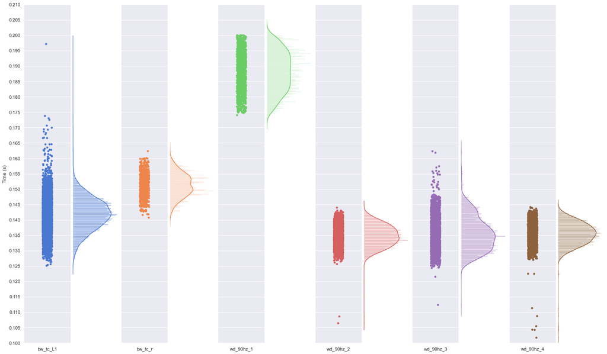

## 8. Future outlook

- New recordings and data analysis using a our Westdrive scenes with the moving camera
- Redo the recordings in a sound isolated room to see if the audio latency detection improves
- Try a new audio engine if there is any that could help getting better results

## Resources

- [Liblsl](https://github.com/sccn/liblsl/releases/latest)
- [LabRecorder](https://github.com/labstreaminglayer/App-LabRecorder/releases)
- LSL4Unity
- liblsl-Csharp
- [LSL Apps](https://github.com/sccn/labstreaminglayer/tree/master/Apps)
- [LSL documentation reference](https://labstreaminglayer.readthedocs.io/)
- [LSL latency analysis](https://github.com/mvidaldp/lsl_latency_analysis)
- [LSL in Unity](https://github.com/mvidaldp/lsl_in_unity)
- [How to install and use LSL tutorial](https://docs.google.com/document/d/1NCLiLwMQpt9QKIw7sOM4N62vdDu3Nyw78928Jpz5VIU/edit?usp=sharing)
- [OpenVibe](http://openvibe.inria.fr/downloads/)
- [Audio tones generator](https://github.com/mvidaldp/pytonegen)